# Brownlows Bets

Kayleen Hernandez

2021-11-24

# 1 Introduction

At the first day of class there are 35 students in Math Statistics class and professor Brownlow always proposes this bet to his students “I will wager $2 to your bet of $1 that at least two people in today’s class have the same birthday. He tells me he has made that bet 637 times so far. Where do you think his profits are? Discuss this in a markdown document

```r
money=vector("numeric",0)
for(i in c(1:1000)){
  money[i]=(profit(35,2,637))
}
```

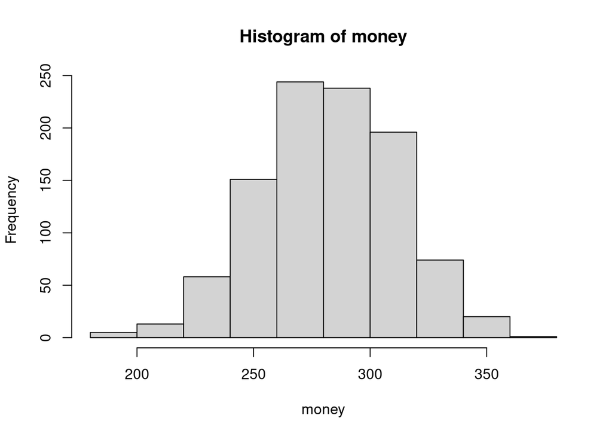

```r
hist(money)
```

Brownlows profits are from 200 to 350.

```r
moneysorted=sort(money)
lci=moneysorted[26]
uci=moneysorted[974]
```

Report git commit structure: There are 3 questions and there should be at least 3 separate commits, at least one dealing with each of the 3 questions. 1. What are the fair odds for a bet on matching birthdays in a 35 person class. 2. For what size class is a 2:1 odds bet fair. 3. How much money would Brownlow be expected to end up with if the bets went as described.

## 1.1 Our strategy is to build a Function and the use it to answer the three questions.

The function will be given a class_size by number of students, odds, and Number_of_times brownlow made the bet. It will give you back how much Brownlows earnings were. We will use it to answer our three questions below. If you can, improve this function by giving default values to some of its inputs.

# 2 In the class and payoff as described If you highered 40 brownlow substitute teachers to do the same thing that Brownlow did then.

## 2.1 what is their average earnings

```r
money=vector("numeric",0)
for(i in c(1:40)){
  money[i]=( profit(35,2,637))
}
```

```r
t.test(money)
```

```
##
##  One Sample t-test
##
## data:  money
## t = 59.378, df = 39, p-value < 2.2e-16
## alternative hypothesis: true mean is not equal to 0
## 95 percent confidence interval:
##  275.678 295.122
## sample estimates:
## mean of x
##     285.4
```

```r
print(sd(money))
```

```
## [1] 30.39889
```

## 2.2 the standard deviationand a 95% confidence interval for thier earnings?

# 3 What are the fair odds? Use manipulation of odds in the function to tune Brownlows earnings to zero.

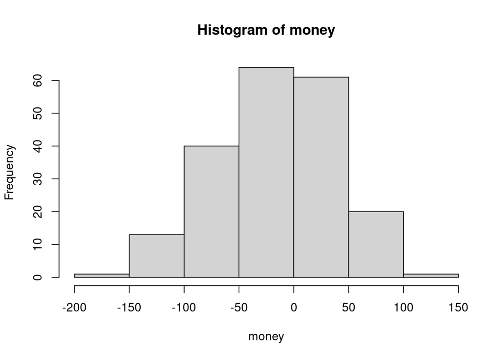

```r
money=vector("numeric", 0)

for(i in c(1:200)){
  money[i]=( profit(35,4.5,637))
}
hist(money)
```

# 4 What size of class makes the 2:1 bet fair? Use manipulation of number of Students to tune Brownlows earnings to zero.

# 5 Discussion and Conclusion